# Analisis Spasial Correlation

Anita Fitria Febrianti

30 September 2019

# instal package untuk spasial autokorelasi

# Autokorelasi Spasial

Anselin (1998) mengenalkan Exploratory Spatial Data Analysis (ESDA) dengan menggunakan autokorelasi spasial (spatial autocorrelation), yaitu suatu analisis yang dapat digunakan untuk mengetahui pola spasial (spatial pattern) dan asosiasi spasial (spatial association).

# input data

```r
#memasukkan SHP untuk melihat gambar peta
gambar <- readShapeSpatial("E:/PETA JATIM 2017 AKB/SHP Nilai Ujian jatim/jatim.shp")
#memasukkan data CSV atau data nilai rata-rata ujian nasional
nilai=read.csv("E:/PETA JATIM 2017 AKB/SHP Nilai Ujian jatim/jatim.csv")
nilai
```

| POLY_ID.N.10.0 | KODE_KAB.N.7.2 | NAMA_KAB.C.50 | KODE_PROP.N.5.2 | NAMA_PROP.C.50 | RATA_RATA_.N.5.2 |
| --- | --- | --- | --- | --- | --- |
| 1 | 3501 | PACITAN | 35 | JAWA TIMUR | 58,16 |
| 2 | 3502 | PONOROGO | 35 | JAWA TIMUR | 57,72 |
| 3 | 3503 | TRENGGALEK | 35 | JAWA TIMUR | 58,93 |
| 4 | 3504 | TULUNGAGUNG | 35 | JAWA TIMUR | 61,95 |
| 5 | 3508 | LUMAJANG | 35 | JAWA TIMUR | 57,22 |
| 6 | 3511 | BONDOWOSO | 35 | JAWA TIMUR | 52,71 |
| 7 | 3514 | PASURUAN | 35 | JAWA TIMUR | 59,51 |
| 8 | 3517 | JOMBANG | 35 | JAWA TIMUR | 60,07 |
| 9 | 3518 | NGANJUK | 35 | JAWA TIMUR | 56,3 |
| 10 | 3519 | MADIUN | 35 | JAWA TIMUR | 57 |

[output cut: 28 more lines]

# Jawa Timur sendiri terdiri dari 38 kabupaten dan kota

dari hasil diatas diperoleh nilai tertinggi untuk rata-rata ujian nasional di jawa Timur berada pada kota malang sebesar 71,31 dan nilai terendah terletak pada kabupaten sampang yakni sebesar 47,27.

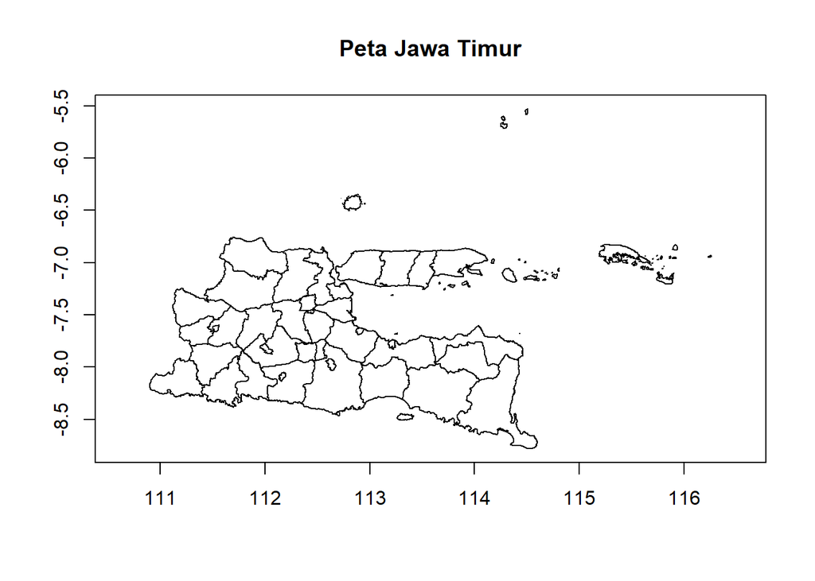

```r
plot(gambar, main="Peta Jawa Timur",axes=TRUE)#axes menentukan sumbu
```

# memunculkan nilai deskriptif dari data

```r
#statistika Deskriptif
summary(nilai$RATA_RATA_)
```

```
## 47,27 48,48 49,51 51,06 52,23 52,71 53,96 55,62 55,79 55,83  56,3 56,68
##     1     1     1     1     1     1     1     1     1     1     1     1
##    57 57,22 57,72 57,96 58,11 58,16 58,69 58,72 58,93 59,51  59,6 59,66
##     1     1     1     1     1     1     1     1     1     1     1     1
## 59,86 60,07 60,65  61,6 61,95 62,17 62,26 62,34 62,74  64,4 65,31 66,48
##     1     1     1     1     1     1     1     1     1     1     1     1
## 67,84 71,31
##     1     1
```

```r
#menentukan pembobotan pada tiap wilayah
#jumlah kedekatan antar lokasi
queen.w=poly2nb(gambar, row.names=gambar$kabupaten,queen=TRUE)
summary(queen.w)
```

```
## Neighbour list object:
## Number of regions: 38
## Number of nonzero links: 140
## Percentage nonzero weights: 9.695291
## Average number of links: 3.684211
## Link number distribution:
##
## 1 2 3 4 5 6 7 8 9
## 8 6 5 7 2 6 2 1 1
## 8 least connected regions:
## 15 17 18 19 20 21 22 37 with 1 link
## 1 most connected region:
## 32 with 9 links
```

# jumlah kedekatan antar lokasi

terdapat 8 kabupaten dan kota yang memiliki jumlah kedekatan 1, dan terdapat 6 kabupaten dan kota yang memiliki jumlah kedekatan sebanyak 2 ,dan terdapat 1 kabupaten yang memiliki jumlah kedekatan dengan kabupaten dan kota lain sebanyak 9. #

```r
#queen.w sama queen.c(untuk mengetahui nilai kontiguiti)
queen.c=poly2nb(gambar, row.names=gambar$RATA_RATA_)
summary(queen.c)
```

```
## Neighbour list object:
## Number of regions: 38
## Number of nonzero links: 140
## Percentage nonzero weights: 9.695291
## Average number of links: 3.684211
## Link number distribution:
##
## 1 2 3 4 5 6 7 8 9
## 8 6 5 7 2 6 2 1 1
## 8 least connected regions:
## 52.23 66.48 62.34 71.31 62.17 59.66 60.65 48.48 with 1 link
## 1 most connected region:
## 61.6 with 9 links
```

```r
str(queen.c)
```

```
## List of 38
##  $ : int [1:2] 2 3
##  $ : int [1:6] 1 3 4 9 10 11
##  $ : int [1:3] 1 2 4
##  $ : int [1:5] 2 3 9 27 28
##  $ : int [1:4] 7 32 33 34
##  $ : int [1:4] 30 32 34 37
##  $ : int [1:7] 5 22 26 29 33 34 36
##  $ : int [1:6] 9 13 15 28 29 33
##  $ : int [1:6] 2 4 8 10 13 28
##  $ : int [1:6] 2 9 11 12 13 24
##  $ : int [1:4] 2 10 12 24
##  $ : int [1:3] 10 11 13
##  $ : int [1:6] 8 9 10 12 14 15
##  $ : int [1:2] 13 15
```

[output cut: 29 more lines]

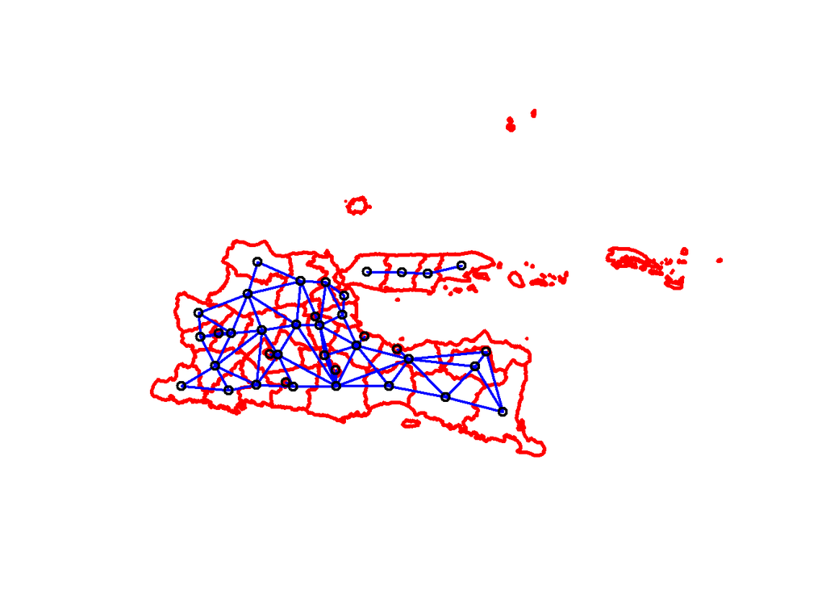

```r
plot(gambar, col="white", border="red", lwd="3")
plot(queen.c, coordinates(gambar),add=TRUE, lwd="2",col="blue")
```

```r
#menentukan karakteristik antar lokasi
#standarisasi matriks queen contiguity
queen.w1=nb2listw(queen.w, style="W")
summary(queen.w1)
```

```
## Characteristics of weights list object:
## Neighbour list object:
## Number of regions: 38
## Number of nonzero links: 140
## Percentage nonzero weights: 9.695291
## Average number of links: 3.684211
## Link number distribution:
##
## 1 2 3 4 5 6 7 8 9
## 8 6 5 7 2 6 2 1 1
## 8 least connected regions:
## 15 17 18 19 20 21 22 37 with 1 link
## 1 most connected region:
## 32 with 9 links
##
## Weights style: W
## Weights constants summary:
##    n   nn S0       S1       S2
## W 38 1444 38 26.78738 169.3149
```

```r
#menentukan nilai matriks antar lokasi queen untuk mencari karakteristik kedekatan antar lokasi
queen.m=nb2mat(queen.w, style="W")
queen.m
```

```
##         [,1]      [,2]      [,3]      [,4]      [,5]      [,6]      [,7]
## 0  0.0000000 0.5000000 0.5000000 0.0000000 0.0000000 0.0000000 0.0000000
## 1  0.1666667 0.0000000 0.1666667 0.1666667 0.0000000 0.0000000 0.0000000
## 2  0.3333333 0.3333333 0.0000000 0.3333333 0.0000000 0.0000000 0.0000000
## 3  0.0000000 0.2000000 0.2000000 0.0000000 0.0000000 0.0000000 0.0000000
## 4  0.0000000 0.0000000 0.0000000 0.0000000 0.0000000 0.0000000 0.2500000
## 5  0.0000000 0.0000000 0.0000000 0.0000000 0.0000000 0.0000000 0.0000000
## 6  0.0000000 0.0000000 0.0000000 0.0000000 0.1428571 0.0000000 0.0000000
## 7  0.0000000 0.0000000 0.0000000 0.0000000 0.0000000 0.0000000 0.0000000
## 8  0.0000000 0.1666667 0.0000000 0.1666667 0.0000000 0.0000000 0.0000000
## 9  0.0000000 0.1666667 0.0000000 0.0000000 0.0000000 0.0000000 0.0000000
## 10 0.0000000 0.2500000 0.0000000 0.0000000 0.0000000 0.0000000 0.0000000
## 11 0.0000000 0.0000000 0.0000000 0.0000000 0.0000000 0.0000000 0.0000000
## 12 0.0000000 0.0000000 0.0000000 0.0000000 0.0000000 0.0000000 0.0000000
## 13 0.0000000 0.0000000 0.0000000 0.0000000 0.0000000 0.0000000 0.0000000
```

[output cut: 182 more lines]

# didapatkan matriks 38*38 untuk pembobot (W)

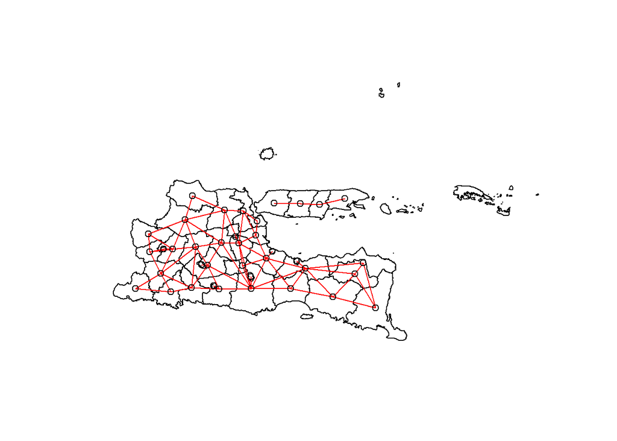

```r
#memetakan peta jawa timur dengan koordinat antar wilayah
plot(gambar, border="black")
plot.queen= plot(queen.w, coordinates(gambar),add=TRUE, col="red")
```

#Hipotesis H0: IM = 0(tidak ada autokorelasi spasial) H1: IM=/ 0 (ada autokorelasi spasial)

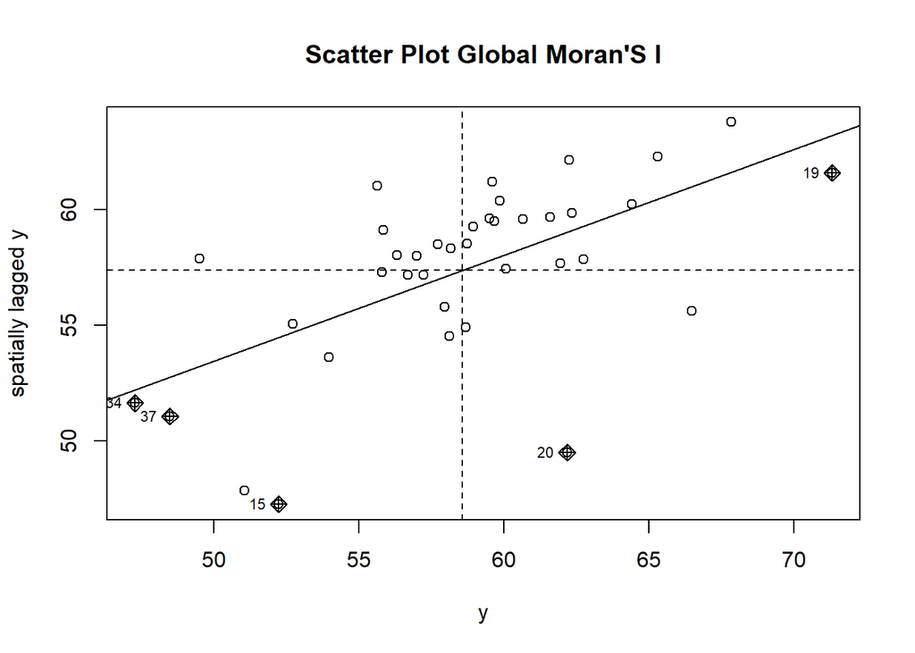

```r
#membuat scatter plot pada rata-rata nilai
r.queen.s=mat2listw(queen.m, style="W")
y=gambar$RATA_RATA_
moran.plot(y,r.queen.s, main="Scatter Plot Global Moran'S I")
```

#dari gambar scatterplot Moran’s scatter plot terdiri dari 4 kuadran (Anselin, 2005). Kuadran high-high (upper right) / kuadran I dan low-low (lower left) / kuadran III menunjukkan autokorelasi spasial (spatial autocorrelation) positif,high-low/kuadran IV dan low-high/kuadran II menunjukkan autokorelasi spasial (spatial autocorrelation) negatif.

dapat dilihat bahwa data menunjukkan bahwa garis regresi mengarah kekanan yang artinya terdapat autokorelasi positif

```r
#melakukan pengujian global moran's
globalmorans=moran.test(y, listw=queen.w1, alternative="two.sided")
globalmorans
```

```
##
##  Moran I test under randomisation
##
## data:  y
## weights: queen.w1
##
## Moran I statistic standard deviate = 3.7527, p-value = 0.000175
## alternative hypothesis: two.sided
## sample estimates:
## Moran I statistic       Expectation          Variance
##        0.45697537       -0.02702703        0.01663465
```

# Global Moran’s I

```r
#melakukan pengujian local indication spatial autocorrelation(Lisa)
localmorans= localmoran(y, listw=queen.w1,alternative="two.sided")
localmorans
```

```
##               Ii        E.Ii     Var.Ii        Z.Ii   Pr(z != 0)
## 0   0.0039108347 -0.02702703 0.45732044  0.04574883 9.635104e-01
## 1   0.0020091151 -0.02702703 0.13616540  0.07868746 9.372812e-01
## 2   0.0097935917 -0.02702703 0.29674292  0.06759287 9.461097e-01
## 3  -0.1156363925 -0.02702703 0.16828090 -0.21600421 8.289845e-01
## 4   0.0725401791 -0.02702703 0.21645416  0.21400965 8.305395e-01
## 5   0.7940142140 -0.02702703 0.21645416  1.76474518 7.760660e-02
## 6   0.0378762182 -0.02702703 0.11322575  0.19288293 8.470507e-01
## 7  -0.0645901105 -0.02702703 0.13616540 -0.10179533 9.189191e-01
## 8   0.0479518882 -0.02702703 0.13616540  0.20319161 8.389853e-01
## 9   0.0351967623 -0.02702703 0.13616540  0.16862543 8.660913e-01
## 10 -0.0002076413 -0.02702703 0.21645416  0.05764556 9.540310e-01
## 11  0.1024476678 -0.02702703 0.29674292  0.23768113 8.121284e-01
## 12  0.1359668024 -0.02702703 0.13616540  0.44171056 6.586987e-01
## 13  0.0652375006 -0.02702703 0.45732044  0.13643458 8.914777e-01
```

[output cut: 28 more lines]

# LOcal Moran’s I

Menyajikan pengujian statistik untuk mengetahui autokorelasi spasial disetiap wilayah pada suatu variabel, dimana dapat mengukur hubungan spasial untuk setiap lokasi atau korelasi dengan setiap nilai yang berdekatan.

dari hasil output didapatkan bahwa terdapat 6 kabupaten dan kota yang memiliki dependensi dalam indikator nilai rata-rata ujian nasional diwilayah jawa timur dengan tingkat kepercayaan 95% dengan demikian dapat disimpulkan bahwa wilayah tersebut memiliki keterkaitan spasial dengan wilayah terdekatnya.